# RNAseq Analysis BRN

sfhart

2022-09-27

The purpose of this challenge is to complete a full RNA-Seq analysis, including interpretation of the results in a biological context. You should pretend that you are making a report that you want to show to a biomedical collaborator who does not know bioinformatics. You should have an introduction in which you outline the research question, a results section in which you present your results, and a discussion section in which you interpret the results. It should be formatted in an aesthetic way that is easy to follow. Pre-requisite: R for Data Science/

Find an RNA-Seq dataset and perform differential gene expression analysis to determine the effect of some condition on gene expression. I would recommend finding a dataset from recount2, but you can also use GEO as long as you are certain that you have obtained raw read count data and not normalized data. Additionally, your dataset must have at least 3 replicates in two or more biological conditions of interest (e.g., 3 cancer samples vs 3 normal samples). For example, ERP010786 (in recount2) would be is a suitable study. To get the data for this study, simply download the read counts from recount2 (the RSE_v2 file) – this can be loaded into R with the load() command. The data will be loaded in a RangedSummarizedExperiment object – see the resources below to learn how to use this for the analysis.

```r
load("SRP038101.Rdata")
# rse_gene
```

**Here we compare AML3 cells that were treated with Azacytidine and compared against untreated cells, both in cell culture. Three replicates of each group were characterized by RNAseq, and the read counts for each gene were downloaded from an online database**

## 1. Use DESeq2 for the differential gene expression analysis. Find the DEGs between your conditions of interest.

Make sure to add an interactable table of DEGs using a package such as DT

```r
# Make reference table of treatments
data_treatments <- data.frame(row.names = rse_gene$run, treatment = rse_gene$title) %>%
  separate(treatment, into = c("treatment", "replicate"))
# data_treatments

# Run DESeq2
deseq_data <- DESeqDataSetFromMatrix(
  countData = assay(rse_gene),
  colData = data_treatments,
  design = ~treatment
)
deseq_run <- DESeq(deseq_data)
deseq_result <- results(deseq_run, name = "treatment_Untreated_vs_Treated")

# Print out table of 1000 most significant genes
deseq_p0.05 <- deseq_result %>%
  as.data.frame() %>%
  filter(padj < 0.05) %>%
  arrange(padj)
deseq_p0.05_count <- nrow(deseq_p0.05)
output_note <- paste0("\nTotal differential expressed genes with adjusted p<0.05: ", deseq_p0.05_count, "\n(top 1000 shown above)")
head(deseq_p0.05, n = 1000) %>%
  datatable()
```

|  | baseMean | log2FoldChange | lfcSE | stat | pvalue | padj |
| --- | --- | --- | --- | --- | --- | --- |
| ENSG00000070915.9 | 44877.3761607169 | 3.40428681502288 | 0.0768249515176776 | 44.3122546486678 | 0 | 0 |
| ENSG00000090382.6 | 1192054.3299449 | 1.67255962887672 | 0.0405136340103184 | 41.2838707199343 | 0 | 0 |
| ENSG00000164692.17 | 22464.3565407002 | 5.17210315179874 | 0.0808714942190756 | 63.9545887180944 | 0 | 0 |
| ENSG00000165949.12 | 219369.969945587 | 3.39115723539023 | 0.0742308394417565 | 45.6839402719003 | 0 | 0 |
| ENSG00000257764.2 | 368216.030629201 | 1.71948648245411 | 0.0479384128851255 | 35.8686568655184 | 9.41489110201528e-282 | 6.62620035759836e-278 |
| ENSG00000189060.5 | 21102.76968319 | 3.49002639992422 | 0.0986404178134793 | 35.3813018769199 | 3.31110560262028e-274 | 1.9419634359368e-270 |
| ENSG00000204525.15 | 281970.367356467 | 1.40793953589465 | 0.0405849511729484 | 34.6911723484617 | 1.07042331066406e-263 | 5.38117090032403e-260 |
| ENSG00000198865.9 | 6824.06929926128 | 7.12241614104758 | 0.209151677042822 | 34.053832327576 | 3.56181813387404e-254 | 1.56675475163784e-250 |
| ENSG00000187608.8 | 93166.5299590288 | 2.87244383467747 | 0.0876155953879519 | 32.7846181031883 | 9.75530108568655e-236 | 3.81432272450344e-232 |
| ENSG00000234745.9 | 427781.338584157 | 1.42689021875339 | 0.044607691495163 | 31.9875378197527 | 1.62524774406393e-224 | 5.71924681136095e-221 |

[output cut: 990 more lines]

**Total differential expressed genes with adjusted p<0.05: 7676 (top 1000 shown above)**

## 2. Create a PCA plot colored by the condition of interest

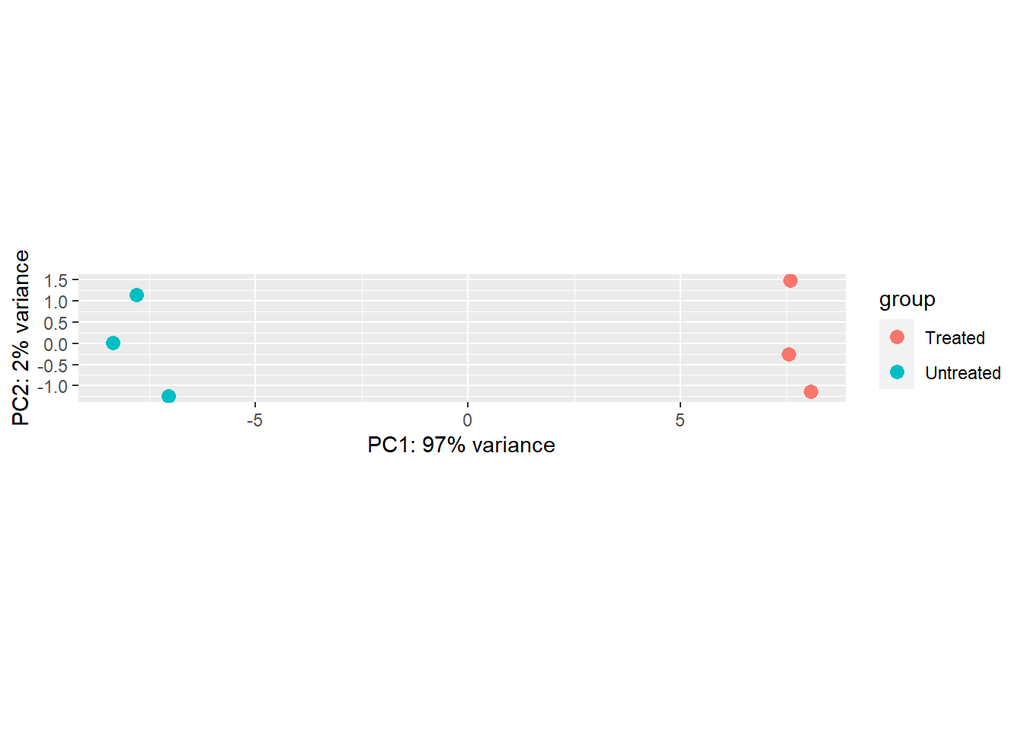

```r
# # Different PCA method
# # Run PCA
#   pca_output <- prcomp(t(assay(rse_gene)))
#
# # Define groups
# groups <- as.factor(data_treatments$treatment)
#
# # Plot
#   pca_plot <- fviz_pca_ind(pca_output,
#                   repel = TRUE,     # Avoid text overlapping
#                   col.ind = groups,
#                   #habillage = groups,
#                   legend.title = "Groups"
#                   )
#   pca_plot

deseq_vsd <- vst(deseq_run, blind = FALSE)
plotPCA(deseq_vsd, intgroup = c("treatment"))
```

## 3. Create a Volcano Plot

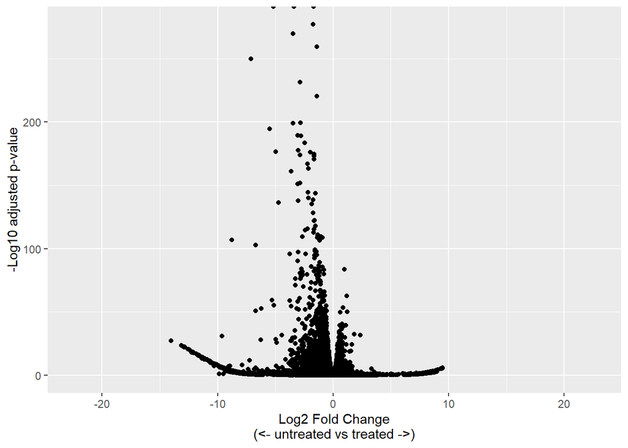

```r
as.data.frame(deseq_result) %>%
  ggplot(aes(-log2FoldChange, -log10(padj))) +
  geom_point() +
  xlab("Log2 Fold Change\n(<- untreated vs treated ->)") +
  ylab("-Log10 adjusted p-value")
```

```r
# assay(rse_gene)["ENSG00000070915.9",]
# groups
```

## 4. Create a heatmap with the top 10 over-expressed DEGs, and top 10 under-expressed DEGs.

Top is defined by DEGs having the lowest adjusted p-values

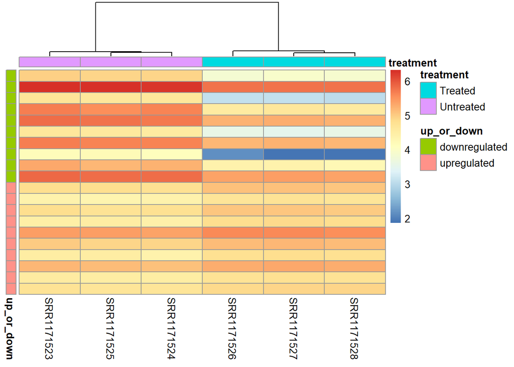

```r
# List of top 10 over- and under-expressed genes
downreg <- deseq_p0.05 %>%
  filter(log2FoldChange > 0) %>%
  head(n = 10) %>%
  row.names()
upreg <- deseq_p0.05 %>%
  filter(log2FoldChange < 0) %>%
  head(n = 10) %>%
  row.names()
up_down <- c(downreg, upreg)
up_down_labels <- data.frame(up_or_down = c(rep("downregulated", 10), rep("upregulated", 10)), row.names = up_down)


# Plot log-transformed heatmap
assay(deseq_run)[downreg, ] %>%
  rbind(., assay(deseq_run)[upreg, ]) %>%
  log10() %>%
  pheatmap(
    cluster_rows = FALSE,
    show_rownames = FALSE,
    cluster_cols = TRUE,
    annotation_col = select(data_treatments, treatment),
    annotation_row = up_down_labels
  )
```

## 5. Do GSEA on the results and plot the top 5 pathways.

For your ranking metric, use the stat column from your DESeq2 results. Top is defined by pathways with the lowest adjusted p-values

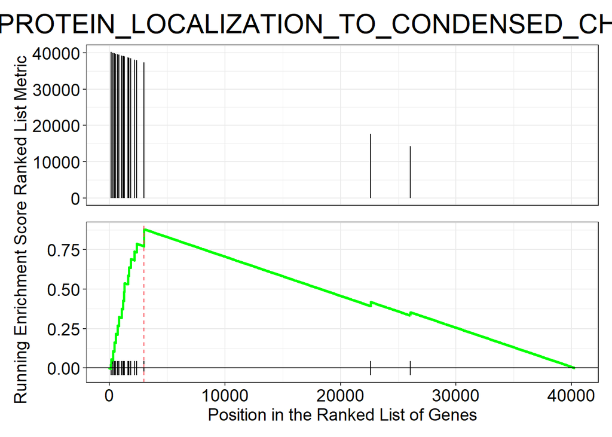

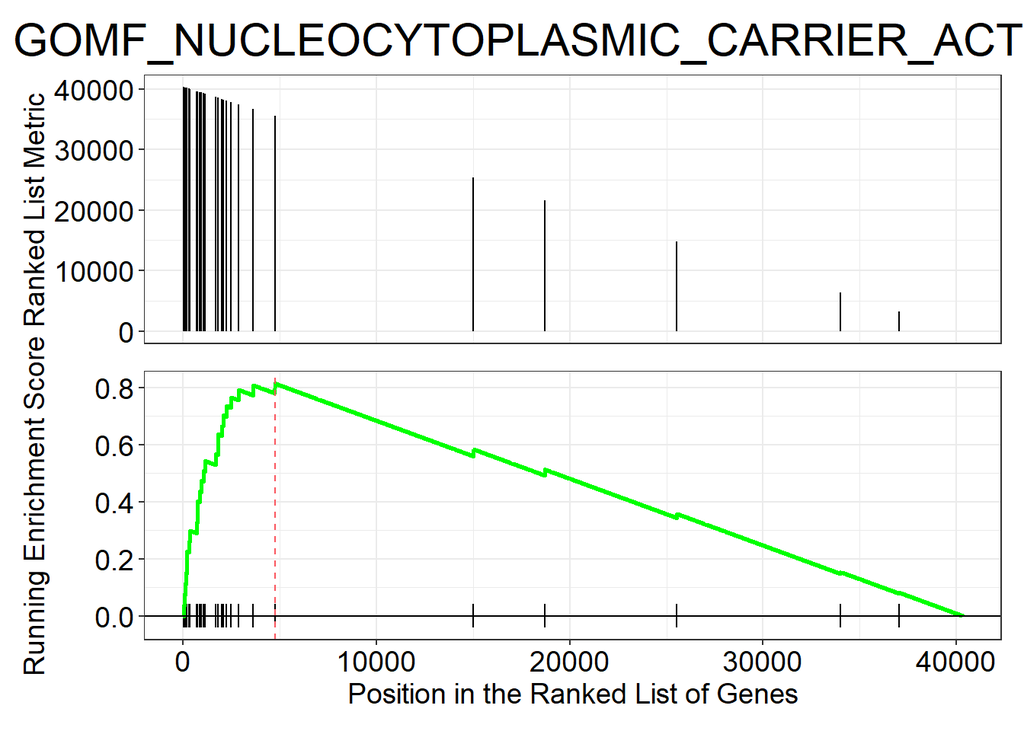

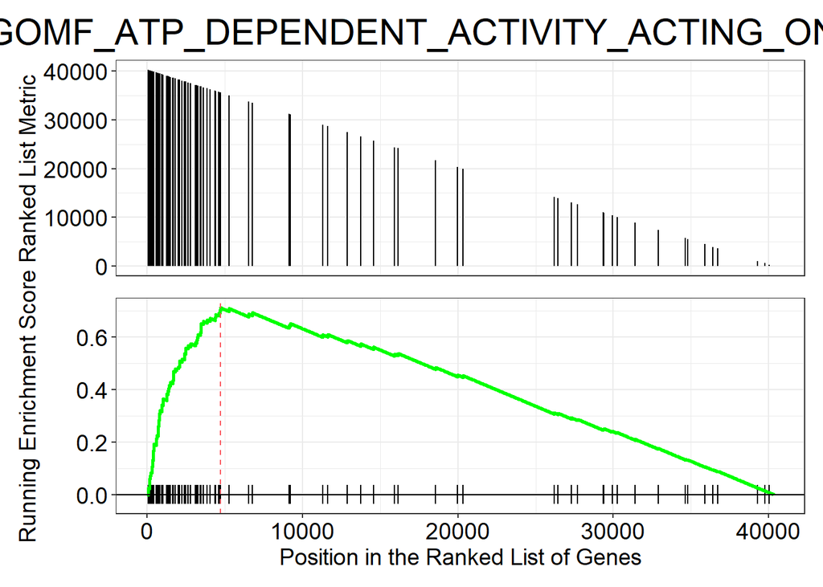

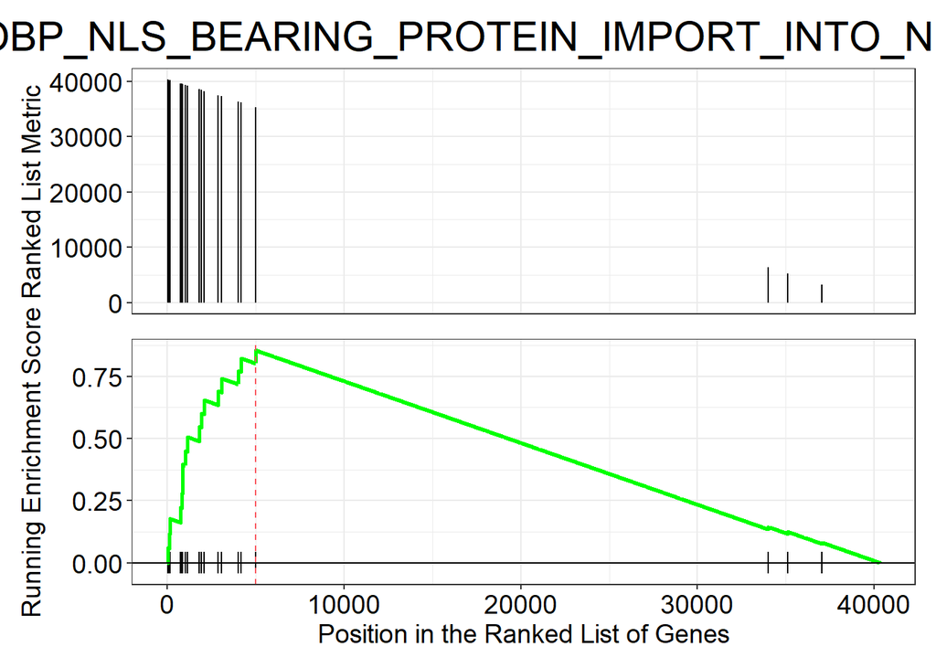

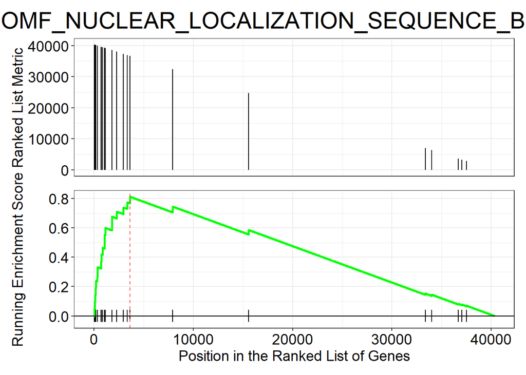

```r
# Download gene sets
C5_gene_sets <- msigdbr(species = "Homo sapiens", category = "C5")
C5_gene_sets <- C5_gene_sets %>%
  select(gs_name, ensembl_gene)
# head(C5_gene_sets)

# Ranked list of genes from our data
deseq_ranking_names <- deseq_result %>%
  as.data.frame() %>%
  rownames_to_column(var = "gene") %>%
  separate(gene, into = c("gene_name", NA)) %>%
  distinct(gene_name, .keep_all = TRUE) %>%
  filter(!is.na(stat)) %>%
  mutate(rank = rank(-stat, ties.method = "random")) %>%
  arrange(desc(rank)) %>%
  select(gene_name, rank) %>%
  deframe()
# head(deseq_ranking_names)

# Run GSEA
gsea_output <- GSEA(
  geneList = deseq_ranking_names,
  TERM2GENE = C5_gene_sets
)

# plot top 5
gsea_output_df <- as.data.frame(gsea_output)
gsea_top5 <- head(gsea_output_df, n = 5) %>%
  row.names()
#view(gsea_output_df)
for (rep in gsea_top5) {
  gseaplot(gsea_output,
    geneSetID = rep,
    title = rep
  ) %>%
    print()
}
```

## 7. What do the results tell you about your conditions of interest? What is the biological meaning of these results? What future experiments could you perform? (These questions don’t have an exact right answer, just about thinking through the meaning of the results).

**This data set was comparing AML cells in culture with and without treatment with Azacytidine, a hypomethylating chemotherapy agent. This treatment resulted in very significant differences between the treatment sets, as evidenced in particular by the number of significantly differentially expressed genes (>7500) and obvious clustering between sets in the PCA. This is not surprising, given that hypomethylation would be expected to affect gene expression genome-wide. Interestingly, this resulted in overall more DOWN-regulation than UP-regulation, which was the opposite of what I would have expected (I generally associate hypomethylation with higher expression of genes). In the gene set enrichment analysis, a number of the top hits were related to nuclear localization of proteins, which means that the chemotherapy agent likely led to the relative overexpression of these genes. This may indicate that the chemotherapy leads the cell to express these genes and import proteins into the nucleus, perhaps as either or a survival mechanism of the cell in response to treatment, or alternatively this may be a reflection of the cytotoxic effects of the chemotherapy agent itself. To follow up on the finding I would be interested to characterize AML expression within patients (this data is from cell culture), before and after chemotherapy treatment to see if any of the results here are recapitulated in relevant settings for patient treatment.**